# deca_16Sordination

Dylan Barth

2026-2-23

## Import data

As always, we begin by importing the data and preprocessing it for our main algorithm. For NMDS, we can use an n x p (samples x species/asv) matrix derived from the otu table.

```r
ps <- readRDS('data/16Sdada2/phyloseq.filtered.tree.rds')
mat <- data.frame(otu_table(ps))
dim(mat) #ensure samples x species, should have many more species
```

```
## [1]   927 44455
```

```r
#preprocess metadata
timelevs <- c("Jul_2022","Nov_2022","Feb_2023", "Aug_2023","Nov_2023", "Feb_2024","Aug_2024")
treatlevs <- c("Baseline","Control","Water","N", "N+P","N+Water","P","P+Water","N+P+Water")
treatcols <- c("#E3E571","#E5AE71","#71C4E5","#53DF7B","#C0E5A4","#BCE7D6","#DF53B7","#E7BCCC","#804DEF")
mhablevs <- c("SI","SG","SSI","SSG")
mcols <- c("#B897DD","#BCDD97","#B43FEE","#78EE3F")
mshapes <- c(25,10,17,16)

meta <- data.frame(sample_data(ps)) %>%
  rename(Sample=SampleID) %>%
  mutate(SampleDate=factor(SampleDate, levels=timelevs)) %>%
  mutate(Treatment=factor(Treatment, levels=treatlevs)) %>%
  mutate(Microhabitat=factor(Microhabitat, levels=mhablevs))
```

## Generate BC Distance Matrix

NMDS (Non-metric MultiDimensional Scaling) is a dimension reduction technique that works well for ordinal data, due to the fact that this method does not assume that the data are embedded in euclidean space like, say, PCA does. It does, however, require calculating the distance matrix which is an n x n matrix, so it can easily fit in memory. There is a more automated way to do this, with `metaMDS()`, but we will make use of the distance matrix in subsequent analyses. We begin by generating a `bray-curtis` distance matrix, and proceed with generating a phylogenetically informed `unifrac` distance matrix.

```r
X <- vegdist(mat, method='bray')
saveRDS(X, 'data/16Svegan/bray.dist.rds')
```

## Calculate BC NMDS

From this distance matrix, we can calculate the NMDS coordinates of each sample using the `metaMDS()` function. We choose to reduce the data into `k=3` dimensions and return not only NMDS coordinates for samples, but also species using the `wascores = T` argument. The arguments `try` and `trymax` limit the minimum and maximum numbers of random starts in search of stable solutions, each random seed requires its own calculation, the number of which that are allowed to concurrently run is controlled by the argument `parallel`. The argument `maxit` controls the maximum number of gradient descent steps allowed in each random seed.

[output not shown]

## Check BC NMDS fit

Here we ensure that the solution we found is relatively well suited to the dataset. We do this by checking the stress (for NMDS, <0.1 is desirable, >0.2 is unreliable), goodness of fit, and by plotting the observed distance in the distance matrix against the euclidean distance in NMDS space. We expect the correlation to be positive, but not necessarily linear.

```r
print(paste0("Stress of NMDS model: ", out$stress))
```

```
## [1] "Stress of NMDS model: 0.0811507379143489"
```

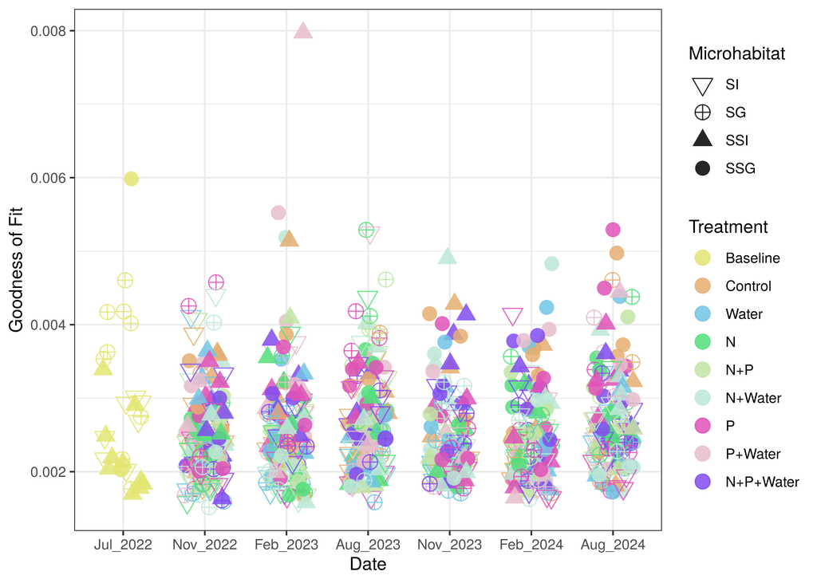

```r
gdat <- data.frame(out$points)
gdat$goodness <- goodness(out)
gdat$Sample <- rownames(gdat)
gdat <- left_join(gdat, meta, by='Sample')

ggplot(gdat)+
  geom_jitter(aes(x=SampleDate, y=goodness, color=Treatment, shape=Microhabitat),
              size=4, height = 0, width=0.25, alpha=0.85)+
  theme_bw()+
  scale_color_manual(values = treatcols)+
  scale_shape_manual(values = mshapes)+
  xlab("Date")+
  ylab("Goodness of Fit")
```

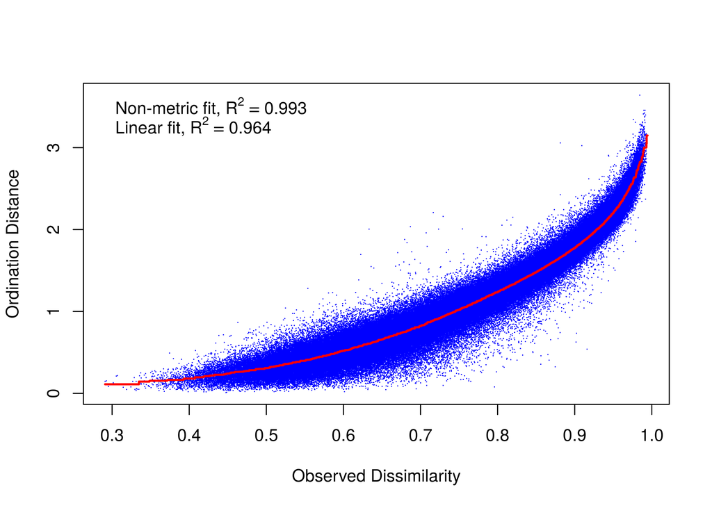

```r
stressplot(out)
```

## Generate BC Ordination Plots

For now, we only graph in two dimensions at a time. Color is mapped to Treatment and shape is mapped to Microhabitat. These graphs show the highest levels of variance within the dataset; a birds eye view. We will later zoom in using the variables that best separate the data to capture a more fine-grained picture.

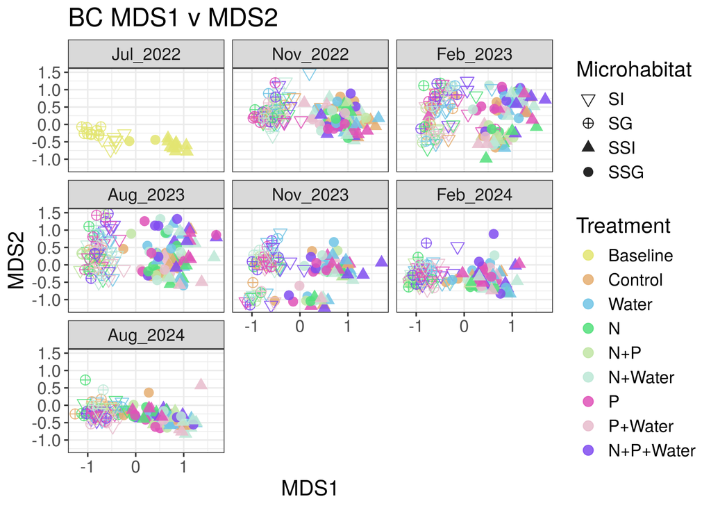

```r
ggplot(gdat)+
  geom_point(aes(x=MDS1, y=MDS2, color=Treatment, shape=Microhabitat),
             size=3, alpha=0.85)+
  theme_bw()+
  theme(text = element_text(size=15))+
  scale_color_manual(values = treatcols)+
  scale_shape_manual(values = mshapes)+
  facet_wrap(~SampleDate)+
  ggtitle('BC MDS1 v MDS2')
```

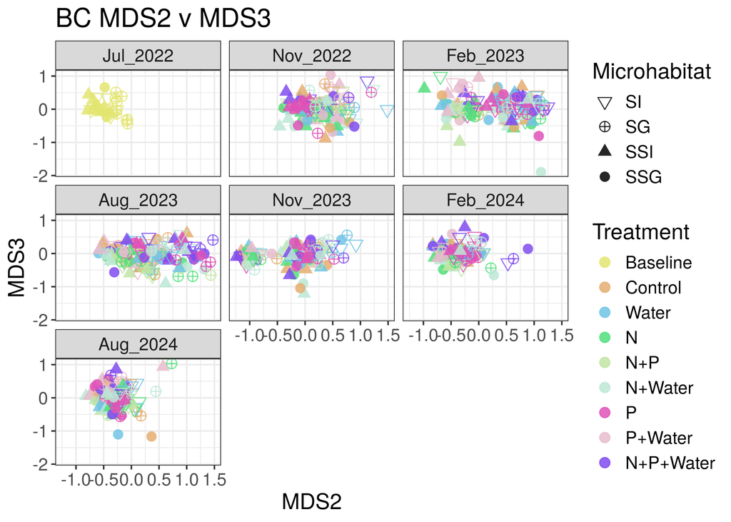

```r
ggplot(gdat)+
  geom_point(aes(x=MDS2, y=MDS3, color=Treatment, shape=Microhabitat),
             size=3, alpha=0.85)+
  theme_bw()+
  theme(text = element_text(size=15))+
  scale_color_manual(values = treatcols)+
  scale_shape_manual(values = mshapes)+
  facet_wrap(~SampleDate)+
  ggtitle('BC MDS2 v MDS3')
```

```r
sidx <- meta %>% filter(Surface_Subsurface=='S') %>% rownames()
ssidx <- meta %>% filter(Surface_Subsurface=='SS') %>% rownames()
sX <- vegdist(mat[sidx,], method='bray')
saveRDS(sX, 'data/16Svegan/surface.bray.dist.rds')
ssX <- vegdist(mat[ssidx,], method='bray')
saveRDS(ssX, 'data/16Svegan/subsurface.bray.dist.rds')

sout <- metaMDS(sX,
               k=3,
               wascores = T,
               weakties=T,
               try=50,
               trymax=100,
               parallel=80,
               maxit=300)
```

```
## *** Best solution repeated 2 times
```

```r
saveRDS(sout, 'data/16Svegan/deca_surface_bray_nmds.rds')
ssout <- metaMDS(ssX,
               k=3,
               wascores = T,
               weakties=T,
               try=50,
               trymax=100,
               parallel=80,
               maxit=300)
```

```
## *** Best solution repeated 1 times
```

```r
saveRDS(ssout, 'data/16Svegan/deca_suburface_bray_nmds.rds')

print(paste0("Stress of Surface BC NMDS model: ", sout$stress))
```

```
## [1] "Stress of Surface BC NMDS model: 0.0965961327330054"
```

```r
print(paste0("Stress of Subsurface BC NMDS model: ", ssout$stress))
```

```
## [1] "Stress of Subsurface BC NMDS model: 0.096330760049428"
```

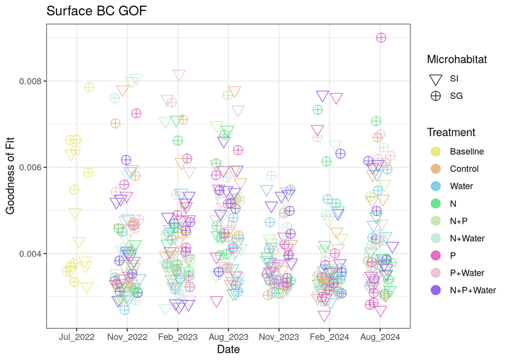

```r
gdat <- data.frame(sout$points)
gdat$goodness <- goodness(sout)
gdat$Sample <- rownames(gdat)
gdat <- left_join(gdat, meta, by='Sample')

ggplot(gdat)+
  geom_jitter(aes(x=SampleDate, y=goodness, color=Treatment, shape=Microhabitat),
              size=4, height = 0, width=0.25, alpha=0.85)+
  theme_bw()+
  scale_color_manual(values = treatcols)+
  scale_shape_manual(values = mshapes)+
  xlab("Date")+
  ylab("Goodness of Fit")+
  ggtitle("Surface BC GOF")
```

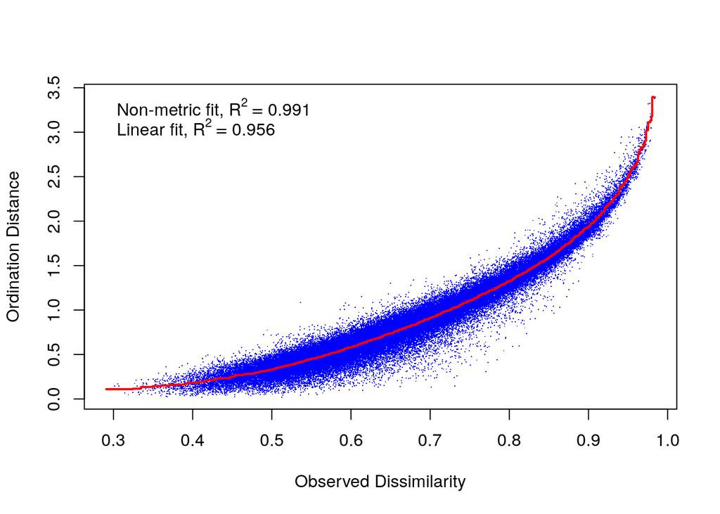

```r
stressplot(sout)
```

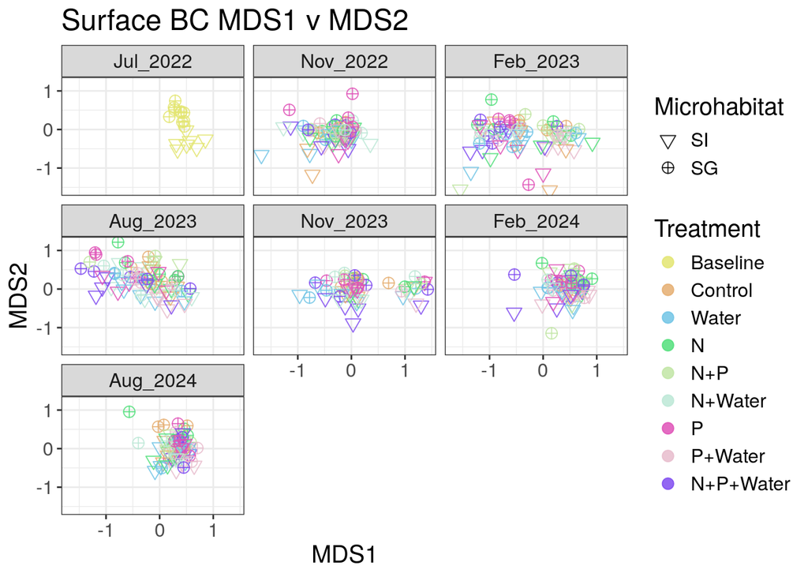

```r
ggplot(gdat)+
  geom_point(aes(x=MDS1, y=MDS2, color=Treatment, shape=Microhabitat),
             size=3, alpha=0.85)+
  theme_bw()+
  theme(text = element_text(size=15))+
  scale_color_manual(values = treatcols)+
  scale_shape_manual(values = mshapes)+
  facet_wrap(~SampleDate)+
  ggtitle('Surface BC MDS1 v MDS2')
```

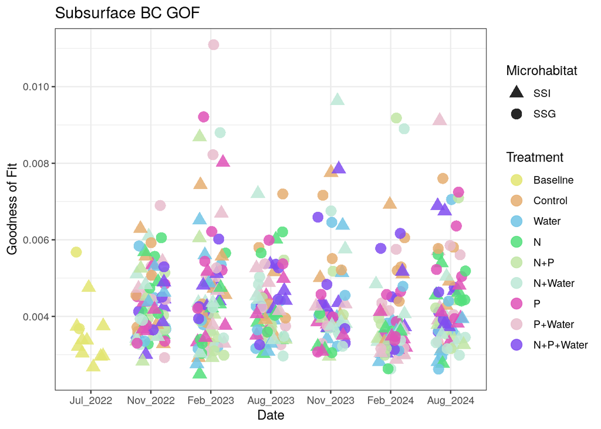

```r
gdat <- data.frame(ssout$points)
gdat$goodness <- goodness(ssout)
gdat$Sample <- rownames(gdat)
gdat <- left_join(gdat, meta, by='Sample')

ggplot(gdat)+
  geom_jitter(aes(x=SampleDate, y=goodness, color=Treatment, shape=Microhabitat),
              size=4, height = 0, width=0.25, alpha=0.85)+
  theme_bw()+
  scale_color_manual(values = treatcols)+
  scale_shape_manual(values = mshapes[3:4])+
  xlab("Date")+
  ylab("Goodness of Fit")+
  ggtitle("Subsurface BC GOF")
```

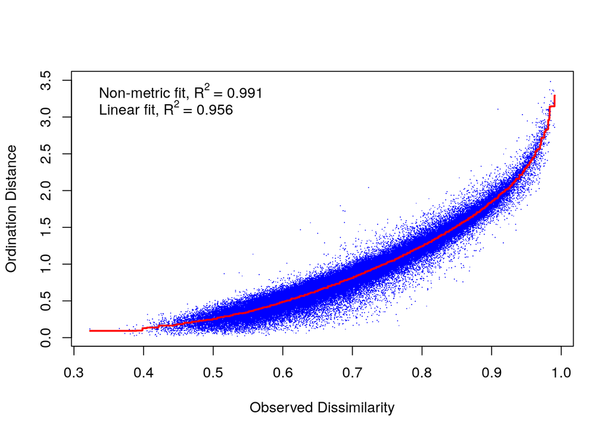

```r
stressplot(ssout)
```

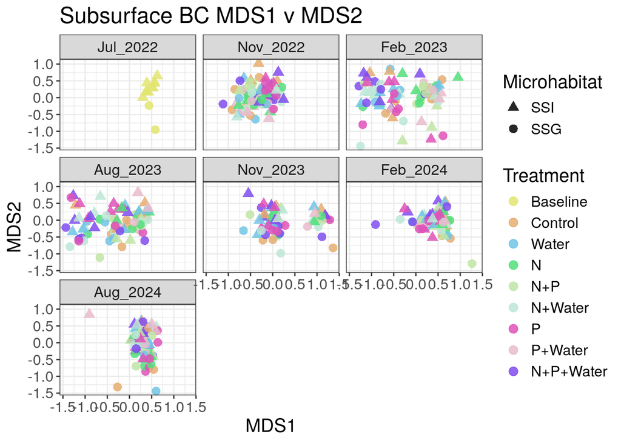

```r
ggplot(gdat)+
  geom_point(aes(x=MDS1, y=MDS2, color=Treatment, shape=Microhabitat),
             size=3, alpha=0.85)+
  theme_bw()+
  theme(text = element_text(size=15))+
  scale_color_manual(values = treatcols)+
  scale_shape_manual(values = mshapes[3:4])+
  facet_wrap(~SampleDate)+
  ggtitle('Subsurface BC MDS1 v MDS2')
```

## Unifrac Unweighted

Here we incorporate the phylogenetic tree into our beta diversity analysis by calculating an unweighted `unifrac` distance matrix. This method takes phylogenetic distance between samples into account. The results are then subject to NMDS to visualize the clustering in lower dimensions. We repeat the steps as above with the `bray-curtis` distance matrix.

```r
library(doParallel)
n <- 20
cl <- makeForkCluster(n)
registerDoParallel(cl)

#prep data for unifrac
keep_taxa <- taxa_names(otu_table(ps))
ps <- prune_taxa(keep_taxa, ps)
ps <- prune_taxa(taxa_sums(ps) > 0, ps)
ps <- subset_samples(ps, sample_sums(ps) > 0)
unweighted <- UniFrac(ps, weighted = F, parallel = T)
#save results
saveRDS(unweighted, "data/16Svegan/unifrac.dist.rds")

#run nmds
out <- metaMDS(unweighted,
               k=3,
               wascores = T,
               weakties=T,
               try=50,
               trymax=100,
               parallel=80,
               maxit=300)
```

```
## *** Best solution was not repeated -- monoMDS stopping criteria:
##     25: no. of iterations >= maxit
##    135: scale factor of the gradient < sfgrmin
```

```r
saveRDS(out, 'data/16Svegan/deca_unifrac_nmds.rds')
```

```r
print(paste0("Stress of Unweighted Unifrac NMDS model: ", out$stress))
```

```
## [1] "Stress of Unweighted Unifrac NMDS model: 0.087691263099678"
```

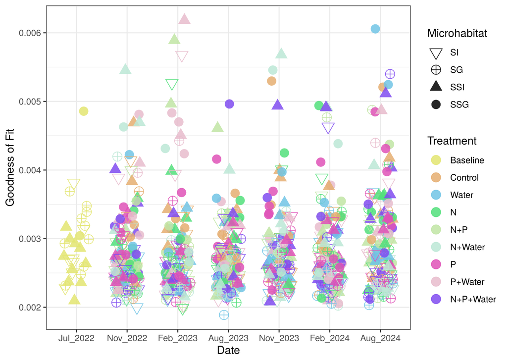

```r
gdat <- data.frame(out$points)
gdat$goodness <- goodness(out)
gdat$Sample <- rownames(gdat)
gdat <- left_join(gdat, meta, by='Sample')

ggplot(gdat)+
  geom_jitter(aes(x=SampleDate, y=goodness, color=Treatment, shape=Microhabitat),
              size=4, height = 0, width=0.25, alpha=0.85)+
  theme_bw()+
  scale_color_manual(values = treatcols)+
  scale_shape_manual(values = mshapes)+
  xlab("Date")+
  ylab("Goodness of Fit")
```

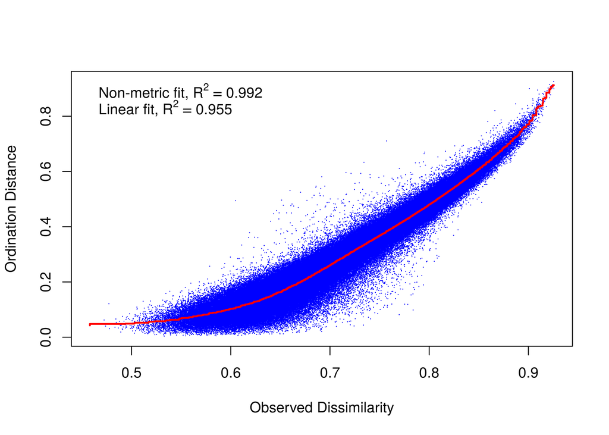

```r
stressplot(out)
```

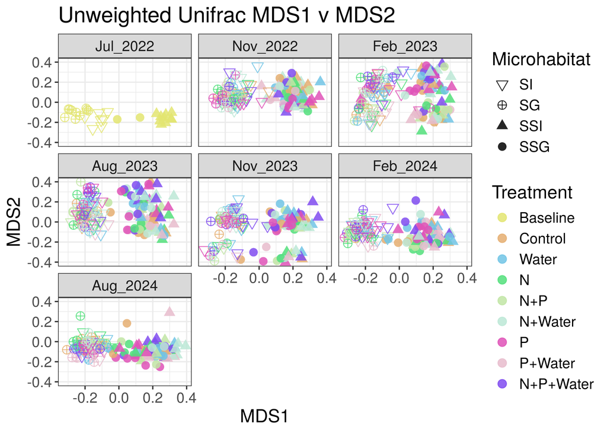

```r
ggplot(gdat)+
  geom_point(aes(x=MDS1, y=MDS2, color=Treatment, shape=Microhabitat),
             size=3, alpha=0.85)+
  theme_bw()+
  theme(text = element_text(size=15))+
  scale_color_manual(values = treatcols)+
  scale_shape_manual(values = mshapes)+
  facet_wrap(~SampleDate)+
  ggtitle('Unweighted Unifrac MDS1 v MDS2')
```

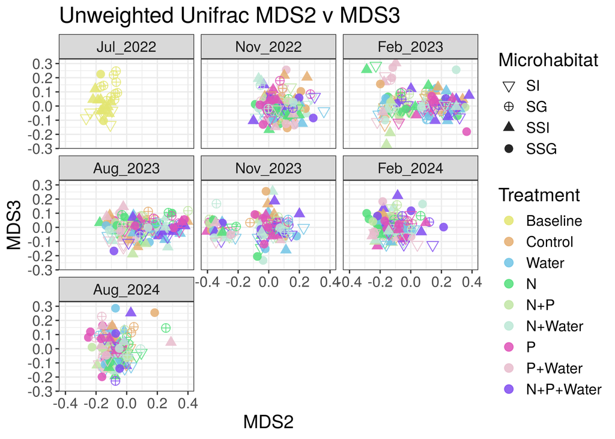

```r
ggplot(gdat)+
  geom_point(aes(x=MDS2, y=MDS3, color=Treatment, shape=Microhabitat),
             size=3, alpha=0.85)+
  theme_bw()+
  theme(text = element_text(size=15))+
  scale_color_manual(values = treatcols)+
  scale_shape_manual(values = mshapes)+
  facet_wrap(~SampleDate)+
  ggtitle('Unweighted Unifrac MDS2 v MDS3')
```

```r
sidx <- meta %>% filter(Surface_Subsurface=='S') %>% rownames()
ssidx <- meta %>% filter(Surface_Subsurface=='SS') %>% rownames()

sX <- UniFrac(subset_samples(ps, sample_names(ps) %in% sidx)  , weighted = F, parallel = T)
saveRDS(sX, 'data/16Svegan/surface.unifrac.dist.rds')

ssX <- UniFrac(subset_samples(ps, sample_names(ps) %in% sidx)  , weighted = F, parallel = T)
saveRDS(ssX, 'data/16Svegan/subsurface.unifrac.dist.rds')

sout <- metaMDS(sX,
               k=3,
               wascores = T,
               weakties=T,
               try=50,
               trymax=100,
               parallel=80,
               maxit=300)
```

```
## *** Best solution was not repeated -- monoMDS stopping criteria:
##      8: no. of iterations >= maxit
##    110: stress ratio > sratmax
##     42: scale factor of the gradient < sfgrmin
```

```r
saveRDS(sout, 'data/16Svegan/deca_surface_unifrac_nmds.rds')
ssout <- metaMDS(ssX,
               k=3,
               wascores = T,
               weakties=T,
               try=50,
               trymax=100,
               parallel=80,
               maxit=300)
```

```
## *** Best solution was not repeated -- monoMDS stopping criteria:
##      5: no. of iterations >= maxit
##    124: stress ratio > sratmax
##     31: scale factor of the gradient < sfgrmin
```

```r
saveRDS(ssout, 'data/16Svegan/deca_suburface_unifrac_nmds.rds')


stopCluster(cl)

print(paste0("Stress of Surface Unweighted Unifrac NMDS model: ", sout$stress))
```

```
## [1] "Stress of Surface Unweighted Unifrac NMDS model: 0.115052484606285"
```

```r
print(paste0("Stress of Subsurface Unweighted Unifrac NMDS model: ", ssout$stress))
```

[output not shown]

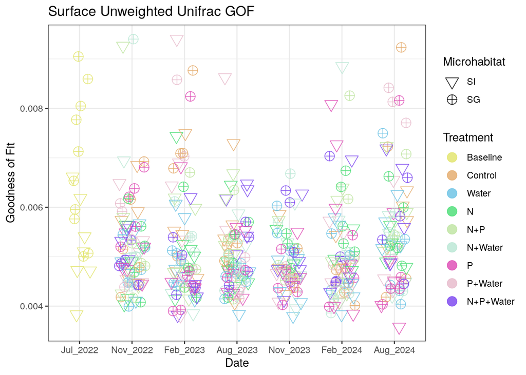

```r
gdat <- data.frame(sout$points)
gdat$goodness <- goodness(sout)
gdat$Sample <- rownames(gdat)
gdat <- left_join(gdat, meta, by='Sample')

ggplot(gdat)+
  geom_jitter(aes(x=SampleDate, y=goodness, color=Treatment, shape=Microhabitat),
              size=4, height = 0, width=0.25, alpha=0.85)+
  theme_bw()+
  scale_color_manual(values = treatcols)+
  scale_shape_manual(values = mshapes)+
  xlab("Date")+
  ylab("Goodness of Fit")+
  ggtitle("Surface Unweighted Unifrac GOF")
```

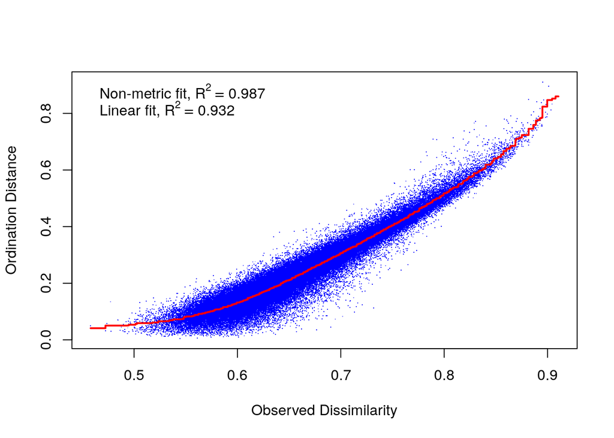

```r
stressplot(sout)
```

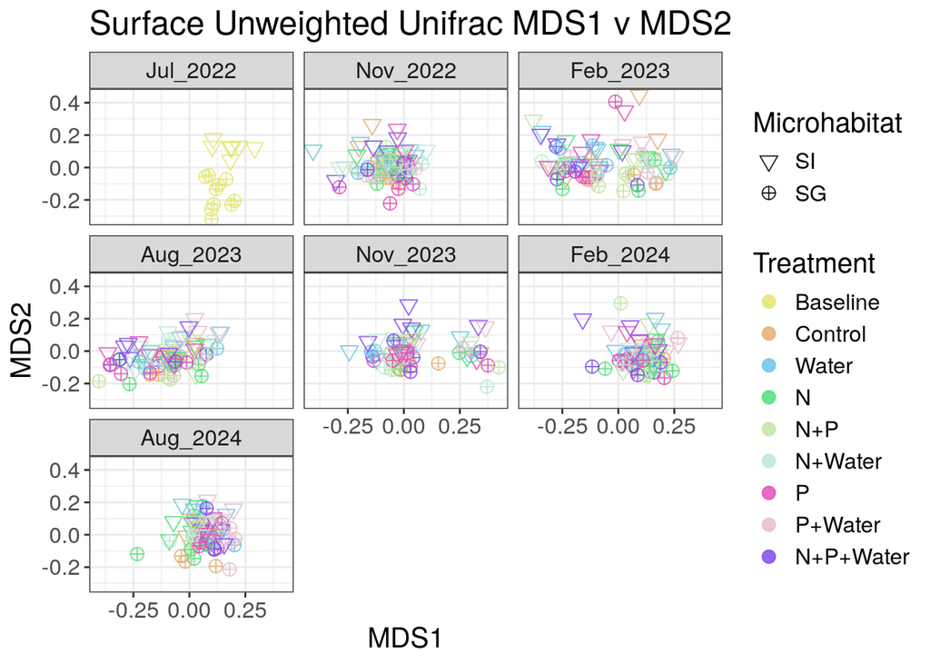

```r
ggplot(gdat)+
  geom_point(aes(x=MDS1, y=MDS2, color=Treatment, shape=Microhabitat),
             size=3, alpha=0.85)+
  theme_bw()+
  theme(text = element_text(size=15))+
  scale_color_manual(values = treatcols)+
  scale_shape_manual(values = mshapes)+
  facet_wrap(~SampleDate)+
  ggtitle('Surface Unweighted Unifrac MDS1 v MDS2')
```

[figure not shown]

```r
gdat <- data.frame(ssout$points)
gdat$goodness <- goodness(ssout)
gdat$Sample <- rownames(gdat)
gdat <- left_join(gdat, meta, by='Sample')

ggplot(gdat)+
  geom_jitter(aes(x=SampleDate, y=goodness, color=Treatment, shape=Microhabitat),
              size=4, height = 0, width=0.25, alpha=0.85)+
  theme_bw()+
  scale_color_manual(values = treatcols)+
  scale_shape_manual(values = mshapes[3:4])+
  xlab("Date")+
  ylab("Goodness of Fit")+
  ggtitle("Subsurface Unweighted Unifrac GOF")
```

[figure not shown]

```r
stressplot(ssout)
```

[figure not shown]

```r
ggplot(gdat)+
  geom_point(aes(x=MDS1, y=MDS2, color=Treatment, shape=Microhabitat),
             size=3, alpha=0.85)+
  theme_bw()+
  theme(text = element_text(size=15))+
  scale_color_manual(values = treatcols)+
  scale_shape_manual(values = mshapes[3:4])+
  facet_wrap(~SampleDate)+
  ggtitle('Subsurface Unweighted Unifrac MDS1 v MDS2')
```